# total RNA

# DEA: CPC vs. CPC-EV

- use edgeR and limma/dream
1. Clean data - remove unpaired items: C938, C1048, C1092; C894 and E894 –> sex not known for this patient
2. Dream approach in variancePartition, patient = random variable

```r
library(variancePartition)
# Filter
coldata2 = coldata %>% dplyr::filter(!rownames(coldata) %in% c("C894","E894", "C938","C1048","C1092"))
str(coldata2)
```

```
## 'data.frame':    52 obs. of  7 variables:
##  $ Type        : Factor w/ 2 levels "C","E": 1 1 1 1 1 1 1 1 1 1 ...
##  $ Patient     : Factor w/ 30 levels "894","896","902",..: 14 15 16 23 26 27 29 30 17 18 ...
##  $ Age (months): int  12 6 6 0 3 5 3 0 2 0 ...
##  $ Age Group   : Factor w/ 3 levels "child","infant",..: 1 2 2 3 2 2 2 3 2 3 ...
##  $ Sex         : Factor w/ 2 levels "F","M": 2 1 2 1 2 1 2 1 2 1 ...
##  $ Batch       : Factor w/ 2 levels "Novogene","Yerkes": 1 1 1 1 1 1 1 1 2 2 ...
##  $ logmonths   : num  1.079 0.778 0.778 0 0.477 ...
```

```r
dge_logcpm_batchcorr2 = as.data.frame(dge_logcpm_batchcorr) %>% dplyr::select(-c("C894","E894", "C938","C1048","C1092"))

dge2 = DGEList(counts = merged_filteredcounts %>% dplyr::select(-c("C894","E894", "C938","C1048","C1092")), group = coldata2$Type)
keep2 = filterByExpr(dge2); table(keep2) # Use filterByExpr with default params
```

```
## keep2
## FALSE  TRUE
##    18  8545
```

```r
dge2 = dge2[keep2, , keep.lib.sizes=FALSE]
dge2 = calcNormFactors(dge2, method = "TMM")
dge2$samples
```

```
##       group lib.size norm.factors
## C1004     C 18602135        1.413
## C1006     C 18973707        1.458
## C1007     C 18432544        1.387
## C1083     C 18775721        1.283
## C1097     C 19466434        1.351
## C1099     C 19379864        1.173
## C2013     C 17518272        1.342
## C2016     C 18141912        1.335
## C1010     C 25469211        1.990
## C1045     C 33362152        2.015
## C1050     C 28572280        1.863
## C1063     C 31187179        1.837
## C1066     C 18854027        1.749
## C1095     C 28075284        2.155
## C902      C 30774062        2.023
## C903      C 25140695        2.047
## C924      C 23853159        1.925
## C925      C 24760560        1.838
## C926      C 28740993        1.652
## C930      C 18466998        1.988
## C956      C 27249164        1.892
## C957      C 23202868        2.242
## C975      C 28261490        1.825
## C1100     C 33712479        1.741
## C896      C 38422033        1.603
## C985      C 44977640        1.799
## E1004     E 10237325        0.992
## E1006     E 22167156        0.433
## E1007     E  8053971        0.178
## E1010     E 15290668        0.345
## E1045     E 17619730        0.587
## E1050     E 19428782        0.346
## E1063     E  7688032        0.737
## E1066     E 18665938        0.175
## E1083     E 12187658        0.418
## E1095     E 12651355        0.228
## E1097     E  9492804        1.398
## E1099     E 11493872        1.294
## E2013     E 10416851        1.529
## E2016     E  4880807        1.287
## E902      E  7071863        0.918
## E903      E 12845602        0.369
## E924      E  7147680        0.975
## E925      E  1711372        1.409
## E926      E  2147803        0.534
## E930      E  5950928        0.289
## E956      E 16916251        0.129
## E957      E   572129        1.577
## E975      E  5037853        0.643
## E1100     E 13342705        1.992
## E896      E 32755965        0.137
## E985      E  5132625        1.661
```

```r
# Dream Approach
# variable tested (Type) must be a fixed effect
form = ~ Batch + Type + Sex + logmonths + (1|Patient)
# estimate weights using linear mixed model of dream
vobjdream = voomWithDreamWeights(dge2, form, coldata2)
```

```
## Memory usage to store result: >35.6 Mb
```

```
## Dividing work into 188 chunks...
```

```
##
## Total:390 s
```

```r
# fit the model to each gene - Satterthwaite approx for hypot.test
fit = dream(vobjdream, form, coldata2)
```

```
## Dividing work into 188 chunks...
```

```
##
## Total:410 s
```

```r
fit = eBayes(fit)
topTable(fit, coef = "TypeE", number = 20) # Get results of hypothesis test on coefficients of interest
```

```
##          logFC AveExpr     t  P.Value adj.P.Val    B  z.std
## THBS1    -4.22   10.87 -21.2 1.24e-26  8.96e-23 45.5 -10.68
## FN1      -3.37   12.09 -21.0 2.49e-26  8.96e-23 45.3 -10.62
## ANP32B    6.01    8.69  22.4 3.17e-26  8.96e-23 48.0  10.59
## KIF1C     4.56    9.66  20.5 5.19e-26  8.96e-23 48.8  10.55
## TRAK2     5.52    7.99  21.5 5.25e-26  8.96e-23 46.7  10.55
## RAB13     7.26    8.11  22.2 8.86e-26  1.26e-22 46.4  10.50
## RASSF3    4.78    6.70  16.6 7.37e-22  8.15e-19 38.4   9.61
## COL4A1   -5.00    8.54 -17.6 7.63e-22  8.15e-19 38.5  -9.60
## EIF3A     3.42    9.44  15.4 1.69e-21  1.61e-18 37.8   9.52
## COL4A2   -3.77    8.75 -16.2 1.31e-20  1.03e-17 35.9  -9.31
## C22orf46  5.76    5.61  15.9 1.33e-20  1.03e-17 35.3   9.31
## NCL       3.54    9.80  14.7 2.65e-20  1.89e-17 35.5   9.23
## COL1A2   -3.81    9.79 -15.2 4.63e-20  2.84e-17 33.7  -9.17
## ZEB1      4.35    7.75  14.7 4.66e-20  2.84e-17 35.3   9.17
## MAP4K4    3.29    9.11  14.2 5.10e-20  2.90e-17 34.6   9.16
## SERPINE1 -3.77    9.87 -16.0 7.49e-20  4.00e-17 35.2  -9.12
## NET1      5.90    5.65  15.2 1.08e-19  5.24e-17 35.0   9.08
## UACA      3.59    8.93  14.9 1.10e-19  5.24e-17 32.8   9.08
## RPL19     2.29    8.95  12.9 1.32e-19  5.94e-17 34.3   9.06
## COL1A1   -3.68   10.66 -14.4 1.91e-19  8.15e-17 31.0  -9.02
```

```r
fit$design
```

```
##       (Intercept) BatchYerkes TypeE SexM logmonths
## C1004           1           0     0    1     1.079
## C1006           1           0     0    0     0.778
## C1007           1           0     0    1     0.778
## C1083           1           0     0    0     0.000
## C1097           1           0     0    1     0.477
## C1099           1           0     0    0     0.699
## C2013           1           0     0    1     0.477
## C2016           1           0     0    0     0.000
## C1010           1           1     0    1     0.301
## C1045           1           1     0    0     0.000
## C1050           1           1     0    0     0.000
## C1063           1           1     0    1     1.556
## C1066           1           1     0    0     0.778
## C1095           1           1     0    1     0.477
## C902            1           1     0    1     1.681
## C903            1           1     0    0     0.000
## C924            1           1     0    1     0.301
## C925            1           0     0    0     0.000
## C926            1           1     0    1     1.146
## C930            1           1     0    1     0.000
## C956            1           1     0    0     0.699
## C957            1           1     0    1     0.845
## C975            1           1     0    1     0.778
## C1100           1           1     0    0     0.000
## C896            1           1     0    0     1.079
## C985            1           1     0    1     0.000
## E1004           1           1     1    1     1.079
## E1006           1           1     1    0     0.778
## E1007           1           1     1    1     0.778
## E1010           1           1     1    1     0.301
## E1045           1           1     1    0     0.000
## E1050           1           1     1    0     0.000
## E1063           1           1     1    1     1.556
## E1066           1           1     1    0     0.778
## E1083           1           1     1    0     0.000
## E1095           1           1     1    1     0.477
## E1097           1           1     1    1     0.477
## E1099           1           1     1    0     0.699
## E2013           1           1     1    1     0.477
```

[output cut: 12 more lines]

```
## E985            1           1     1    1     0.000
## attr(,"assign")
## [1] 0 1 2 3 4
## attr(,"contrasts")
## attr(,"contrasts")$Batch
## [1] "contr.treatment"
##
## attr(,"contrasts")$Type
## [1] "contr.treatment"
##
## attr(,"contrasts")$Sex
## [1] "contr.treatment"
##
## attr(,"msgScaleX")
## character(0)
```

```r
res = topTable(fit, coef = "TypeE", number = 8545)
res %>% arrange(-logFC) %>% head(n=25)
```

```
##          logFC AveExpr     t  P.Value adj.P.Val     B z.std
## CA11      7.56  -0.545 11.24 6.62e-15  9.27e-13 23.37  7.79
## RAB13     7.26   8.107 22.20 8.86e-26  1.26e-22 46.40 10.50
## RASD1     6.56  -0.261  8.12 1.63e-11  7.06e-10 15.55  6.74
## PLEKHA4   6.51   5.177 14.70 2.54e-18  9.04e-16 31.35  8.73
## NEFM      6.49   1.032  7.36 2.52e-09  5.29e-08 11.17  5.96
## C1orf115  6.26   0.962  8.22 1.38e-10  4.49e-09 15.02  6.42
## ANP32B    6.01   8.690 22.39 3.17e-26  8.96e-23 48.02 10.59
## NET1      5.90   5.652 15.22 1.08e-19  5.24e-17 34.97  9.08
## C22orf46  5.76   5.610 15.89 1.33e-20  1.03e-17 35.27  9.31
## CSF1R     5.57  -0.949  7.70 9.90e-10  2.38e-08 11.85  6.11
## KIF21B    5.57  -0.919  6.44 5.70e-08  7.28e-07  8.25  5.43
## TRAK2     5.52   7.995 21.52 5.25e-26  8.96e-23 46.74 10.55
## ERG       5.50  -0.991  6.68 2.04e-08  3.09e-07  9.41  5.61
## CDC42BPG  5.50  -1.088  6.70 5.55e-09  1.02e-07 10.18  5.83
## IL33      5.42   0.127  6.31 7.26e-08  8.94e-07  7.75  5.38
## IL16      5.31  -0.699  5.99 2.21e-07  2.27e-06  7.24  5.18
## DNAH10    5.31   0.230  5.74 2.65e-07  2.65e-06  6.66  5.15
## CGNL1     5.26   5.205 12.72 1.22e-16  2.90e-14 27.18  8.28
## PITPNM3   5.25   0.571  6.89 2.60e-09  5.42e-08 10.97  5.96
## SPTBN4    5.06  -1.010  5.86 4.20e-07  3.91e-06  6.44  5.06
## ROCK1P1   5.00   0.263  6.07 1.62e-07  1.74e-06  7.56  5.24
## GUCY1A2   4.88   0.512  5.46 1.57e-06  1.23e-05  5.34  4.80
## KIAA1211  4.87   0.105  5.71 6.44e-07  5.66e-06  6.10  4.98
## CCDC88C   4.79   0.261  5.96 3.41e-07  3.26e-06  7.48  5.10
## FLG       4.79  -0.349  4.65 1.62e-05  9.03e-05  2.87  4.31
```

```r
res %>% arrange(logFC) %>% head(n=25)
```

```
##           logFC AveExpr      t  P.Value adj.P.Val    B z.std
## CPA4      -5.78    2.63 -10.46 1.28e-15  2.42e-13 24.9 -8.00
## OSMR      -5.44    3.49 -10.15 4.35e-15  6.76e-13 23.8 -7.84
## COL8A1    -5.40    5.08  -9.22 1.85e-13  1.58e-11 20.3 -7.36
## OXTR      -5.37    3.38  -9.17 2.23e-13  1.83e-11 20.1 -7.33
## FSTL3     -5.36    2.74  -9.93 1.06e-14  1.38e-12 22.9 -7.73
## GDF6      -5.15    2.98  -8.96 5.29e-13  3.90e-11 19.2 -7.22
## TNFRSF11B -5.07    3.38  -8.61 2.21e-12  1.31e-10 17.9 -7.02
## COL4A1    -5.00    8.54 -17.58 7.63e-22  8.15e-19 38.5 -9.60
## RECK      -4.94    2.59  -9.48 6.36e-14  6.25e-12 21.2 -7.50
## CHPF      -4.91    3.81  -8.93 6.03e-13  4.26e-11 19.1 -7.20
## SLC16A3   -4.89    3.81  -9.30 1.30e-13  1.15e-11 20.6 -7.41
## P3H4      -4.87    2.76 -10.50 1.07e-15  2.13e-13 25.0 -8.02
## EDIL3     -4.82    5.01  -8.52 3.18e-12  1.80e-10 17.6 -6.97
## UGCG      -4.81    3.08  -9.45 7.34e-14  6.97e-12 21.1 -7.48
## TRAM2     -4.79    4.93  -9.72 2.45e-14  2.72e-12 22.3 -7.62
## ANGPTL4   -4.78    2.65  -8.50 3.72e-11  1.42e-09 15.8 -6.61
## MEGF6     -4.75    4.24  -9.06 2.54e-12  1.48e-10 18.7 -7.00
## GAS6      -4.69    5.47  -8.42 4.92e-12  2.71e-10 17.2 -6.91
## IGFBP3    -4.65    7.37 -11.76 1.33e-15  2.47e-13 24.5 -7.99
## B4GALT1   -4.64    4.58  -8.64 1.99e-12  1.23e-10 18.0 -7.04
## ARSJ      -4.63    2.67  -8.18 1.30e-11  5.90e-10 16.1 -6.77
## CD248     -4.60    2.99  -9.23 2.20e-12  1.31e-10 17.6 -7.02
## PKD1      -4.59    4.86  -8.41 5.02e-12  2.75e-10 17.1 -6.90
## ITGA5     -4.58    5.71  -9.68 2.81e-14  2.97e-12 22.2 -7.61
## DAG1      -4.58    4.08  -9.66 3.13e-14  3.22e-12 22.0 -7.59
```

```r
#write.csv(topTable(fit, coef = "TypeE", number = 8551), "/Volumes/davis-lab/Jess Hoffman/11. Big Seq/11. For Paper/FinalR/dea total rnaseq dream.csv")
```

Volcano Plot

```r
topCell = res[head(order(res$logFC),10),]; topCell
```

```
##           logFC AveExpr      t  P.Value adj.P.Val    B z.std
## CPA4      -5.78    2.63 -10.46 1.28e-15  2.42e-13 24.9 -8.00
## OSMR      -5.44    3.49 -10.15 4.35e-15  6.76e-13 23.8 -7.84
## COL8A1    -5.40    5.08  -9.22 1.85e-13  1.58e-11 20.3 -7.36
## OXTR      -5.37    3.38  -9.17 2.23e-13  1.83e-11 20.1 -7.33
## FSTL3     -5.36    2.74  -9.93 1.06e-14  1.38e-12 22.9 -7.73
## GDF6      -5.15    2.98  -8.96 5.29e-13  3.90e-11 19.2 -7.22
## TNFRSF11B -5.07    3.38  -8.61 2.21e-12  1.31e-10 17.9 -7.02
## COL4A1    -5.00    8.54 -17.58 7.63e-22  8.15e-19 38.5 -9.60
## RECK      -4.94    2.59  -9.48 6.36e-14  6.25e-12 21.2 -7.50
## CHPF      -4.91    3.81  -8.93 6.03e-13  4.26e-11 19.1 -7.20
```

```r
topEV = res[head(order(res$logFC,decreasing = T),10),]; topEV
```

```
##          logFC AveExpr     t  P.Value adj.P.Val    B z.std
## CA11      7.56  -0.545 11.24 6.62e-15  9.27e-13 23.4  7.79
## RAB13     7.26   8.107 22.20 8.86e-26  1.26e-22 46.4 10.50
## RASD1     6.56  -0.261  8.12 1.63e-11  7.06e-10 15.5  6.74
## PLEKHA4   6.51   5.177 14.70 2.54e-18  9.04e-16 31.3  8.73
## NEFM      6.49   1.032  7.36 2.52e-09  5.29e-08 11.2  5.96
## C1orf115  6.26   0.962  8.22 1.38e-10  4.49e-09 15.0  6.42
## ANP32B    6.01   8.690 22.39 3.17e-26  8.96e-23 48.0 10.59
## NET1      5.90   5.652 15.22 1.08e-19  5.24e-17 35.0  9.08
## C22orf46  5.76   5.610 15.89 1.33e-20  1.03e-17 35.3  9.31
## CSF1R     5.57  -0.949  7.70 9.90e-10  2.38e-08 11.9  6.11
```

```r
keyvals = ifelse((res$logFC < -1 & res$adj.P.Val<0.01), 'coral1', ifelse((res$logFC > 1 & res$adj.P.Val<0.01), 'deepskyblue2','black'))
keyvals[is.na(keyvals)] <- 'black'
names(keyvals)[keyvals == 'deepskyblue2'] <- 'EV'
names(keyvals)[keyvals == 'black'] <- 'mid'
names(keyvals)[keyvals == 'coral1'] <- 'Cell'

library(EnhancedVolcano)
```

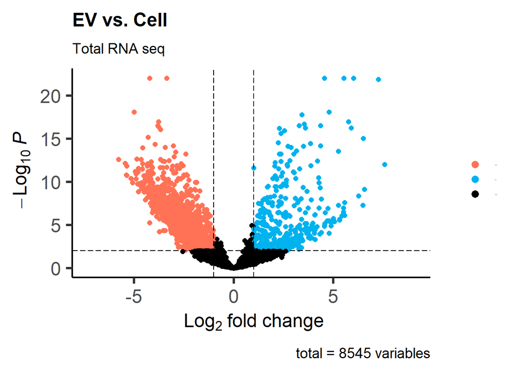

```r
EnhancedVolcano(res, #500x600
                lab = NA,
                x = 'logFC',
                y = 'adj.P.Val',
                pCutoff = 0.01,
                FCcutoff = 1.0,
                selectLab =  c(rownames(topCell),rownames(topEV)),
                title = 'EV vs. Cell',
                subtitle = "Total RNA seq",
                legendPosition = 'right',
                legendLabSize = 1,
                colAlpha = 1,
                gridlines.major = FALSE,
                gridlines.minor = FALSE,
                colCustom = keyvals,
                legendIconSize = 3) + ggplot2::scale_y_continuous(breaks=seq(0,30, 5))
```

# Reviewer 2 assessing age

```r
PCA = prcomp(t(dge_logcpm_batchcorr), scale = FALSE)
percentVar = round(100*PCA$sdev^2/sum(PCA$sdev^2),1)

varloadings = as.data.frame(PCA$rotation) #eigenvectors
top100positive_PC1 = varloadings %>% rownames_to_column("RNA") %>% arrange(-PC1) %>% dplyr::select(c("RNA","PC1")) %>% head(n=100)
top100negative_PC1 = varloadings %>% rownames_to_column("RNA") %>% arrange(PC1) %>% dplyr::select(c("RNA","PC1")) %>% head(n=100)
top100positive_PC2 = varloadings %>% rownames_to_column("RNA") %>% arrange(-PC2) %>% dplyr::select(c("RNA","PC2")) %>% head(n=100)
top100negative_PC2 = varloadings %>% rownames_to_column("RNA") %>% arrange(PC2) %>% dplyr::select(c("RNA","PC2")) %>% head(n=100)

EV_100 = res %>% arrange(-logFC) %>% head(n=100)
Cell_100 = res %>% arrange(logFC) %>% head(n=100)


# Cell - only overlaps with PC1+ and PC2-
length(intersect(top100positive_PC1$RNA,rownames(Cell_100)))
```

```
## [1] 23
```

```r
length(intersect(top100negative_PC2$RNA,rownames(Cell_100)))
```

```
## [1] 30
```

```r
length(intersect(top100negative_PC2$RNA, top100positive_PC1$RNA))
```

```
## [1] 4
```

```r
length(intersect(top100negative_PC2$RNA, intersect(top100positive_PC1$RNA,rownames(Cell_100))))
```

```
## [1] 4
```

```r
# EV - only overlaps with PC1- and PC2+
length(intersect(top100negative_PC1$RNA,rownames(EV_100)))
```

```
## [1] 47
```

```r
length(intersect(top100positive_PC2$RNA,rownames(EV_100)))
```

```
## [1] 38
```

```r
length(intersect(top100positive_PC2$RNA, top100negative_PC1$RNA))
```

```
## [1] 19
```

```r
length(intersect(top100positive_PC2$RNA, intersect(top100negative_PC1$RNA,rownames(EV_100))))
```

```
## [1] 19
```

```r
######## PC and age #############
PCA_scores = as.data.frame(PCA$x)
colnames(PCA_scores) = paste0(colnames(PCA_scores)," - ",percentVar, "% Variance")
PCA_scores = PCA_scores[,1:9]; head(PCA_scores)
```

```
##       PC1 - 31.5% Variance PC2 - 6.5% Variance PC3 - 5.6% Variance
## C1004               1.9028                26.6               -32.8
## C1006               1.7879                46.6               -27.2
## C1007               6.9063               -30.6                29.8
## C1048              11.5030               -61.7                77.5
## C1083              -0.0925               -48.1                69.6
## C1097              10.3694                15.4                -7.8
##       PC4 - 4% Variance PC5 - 3.8% Variance PC6 - 3.7% Variance
## C1004            15.465               -12.4                4.17
## C1006            11.051               -48.6               49.49
## C1007            11.798                24.2              -41.04
## C1048             0.517                22.9              -51.64
## C1083             5.014                52.2              -81.99
## C1097             5.678               -43.5               49.38
##       PC7 - 3.4% Variance PC8 - 3.3% Variance PC9 - 3.2% Variance
## C1004               -6.19               21.81               -9.34
## C1006               -2.47               18.12               10.51
## C1007               -5.79                4.25              -53.95
## C1048              -13.28              -11.38              -61.64
## C1083              -12.94               -5.36              -78.81
## C1097                7.61                5.93               34.57
```

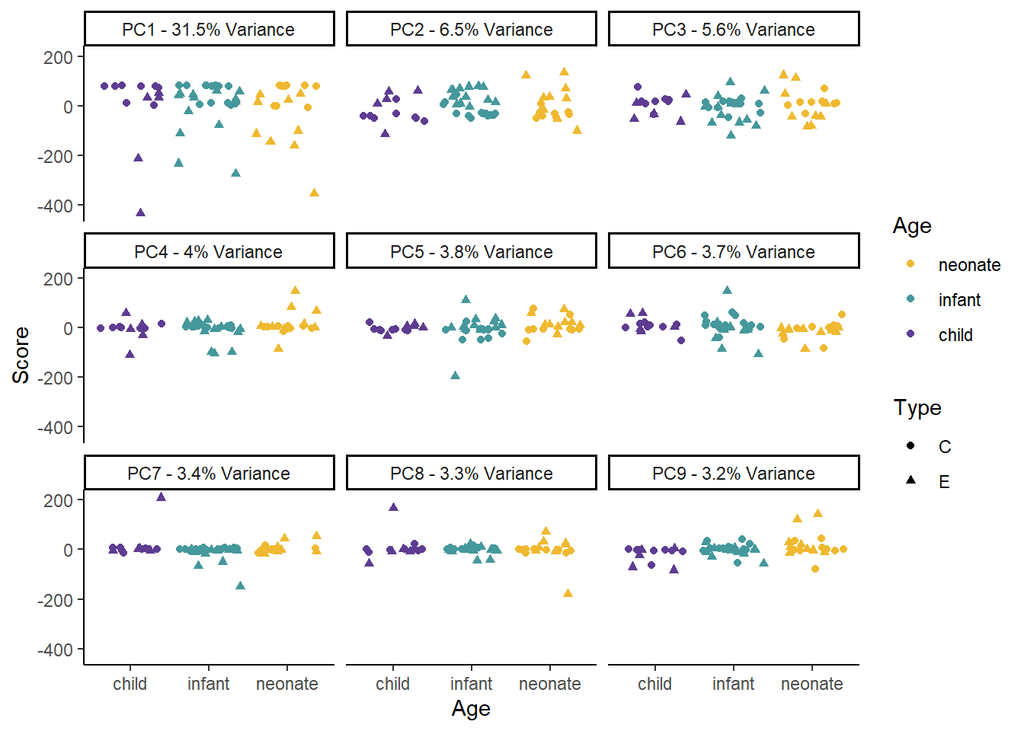

```r
PCA_scores$Age = coldata$`Age Group`; PCA_scores$Type = coldata$Type
PCA_scores %>% pivot_longer(starts_with("PC"), names_to = "PC", values_to = "Score") %>%
  ggplot(aes(x = Age, y = Score))+
  geom_jitter(aes(color = Age, shape = Type))+
  facet_wrap(~PC) +
  scale_color_manual(values = c(neonate = "#EFB931", infant = "#45989B", child = "#5D3C91"))+
  theme_classic()
```

# Table of DE RNAs

```r
library(sjPlot)
results = res
up = results[(results$logFC>1 & results$adj.P.Val<0.05),] %>% arrange(-logFC); dim(up)
```

```
## [1] 488   7
```

```r
down = results[(results$logFC<(-1) & results$adj.P.Val<0.05),] %>% arrange(logFC); dim(down)
```

```
## [1] 4298    7
```

```r
up$RNA = rownames(up)
down$RNA = rownames(down)

#write.csv(up, "Y:/davis-lab/Jess Hoffman/11. Big Seq/11. For Paper/FinalR/upinEV-revisions.csv")
#write.csv(down, "Y:/davis-lab/Jess Hoffman/11. Big Seq/11. For Paper/FinalR/upinCell-revisions.csv")

signif.num <- function(x) {symnum(x, corr = FALSE, na = FALSE, legend = FALSE,
                                  cutpoints = c(0, 1e-10, 1e-5, 1e-2, 0.1, 1),
                                  symbols = c("***", "**", "*", ".", " "))}

up$padj = signif.num(up$adj.P.Val)
down$padj = signif.num(down$adj.P.Val)
colnames(up)[1] = "Log2(EV/Cell)"
colnames(down)[1] = "Log2(Cell/EV)"

up.2 = subset(arrange(up, -`Log2(EV/Cell)`), select=c(RNA,`Log2(EV/Cell)`, padj))
down.2 = subset(arrange(down, `Log2(Cell/EV)`), select=c(RNA,`Log2(Cell/EV)`, padj))

bof = cbind(head(up,25)%>% dplyr::select(c("RNA","Log2(EV/Cell)","padj")), head(down,25) %>% dplyr::select(c("RNA","Log2(Cell/EV)","padj")))
bof$`Log2(Cell/EV)` = -1*(bof$`Log2(Cell/EV)`)

#tab_df(bof, alternate.rows = T, title = "RNAs preferentially released to EV and retained in cell", col.header = c("RNA", "Log2(EV/Cell)", "padj", "RNA", "Log2(Cell/EV)", "padj"), footnote = "*p < 0.01, **p < 1e-5, ***p < 1e-10", show.footnote = T, file="/Volumes/davis-lab/Jess Hoffman/11. Big Seq/11. For Paper/FinalR/top25table_RNA.doc")

# Get top 250 by foldchange
head(up,n=250)
```

```
##              Log2(EV/Cell)   AveExpr     t  P.Value adj.P.Val       B z.std
## CA11                  7.56 -0.544600 11.24 6.62e-15  9.27e-13 23.3710  7.79
## RAB13                 7.26  8.106618 22.20 8.86e-26  1.26e-22 46.4011 10.50
## RASD1                 6.56 -0.260535  8.12 1.63e-11  7.06e-10 15.5485  6.74
## PLEKHA4               6.51  5.176673 14.70 2.54e-18  9.04e-16 31.3459  8.73
## NEFM                  6.49  1.031587  7.36 2.52e-09  5.29e-08 11.1715  5.96
## C1orf115              6.26  0.962129  8.22 1.38e-10  4.49e-09 15.0220  6.42
## ANP32B                6.01  8.690012 22.39 3.17e-26  8.96e-23 48.0166 10.59
## NET1                  5.90  5.651651 15.22 1.08e-19  5.24e-17 34.9747  9.08
## C22orf46              5.76  5.610420 15.89 1.33e-20  1.03e-17 35.2746  9.31
## CSF1R                 5.57 -0.949242  7.70 9.90e-10  2.38e-08 11.8520  6.11
## KIF21B                5.57 -0.919387  6.44 5.70e-08  7.28e-07  8.2517  5.43
## TRAK2                 5.52  7.994676 21.52 5.25e-26  8.96e-23 46.7364 10.55
## ERG                   5.50 -0.991176  6.68 2.04e-08  3.09e-07  9.4055  5.61
## CDC42BPG              5.50 -1.088451  6.70 5.55e-09  1.02e-07 10.1799  5.83
## IL33                  5.42  0.127462  6.31 7.26e-08  8.94e-07  7.7509  5.38
## IL16                  5.31 -0.699218  5.99 2.21e-07  2.27e-06  7.2378  5.18
## DNAH10                5.31  0.229895  5.74 2.65e-07  2.65e-06  6.6591  5.15
## CGNL1                 5.26  5.204599 12.72 1.22e-16  2.90e-14 27.1783  8.28
## PITPNM3               5.25  0.570583  6.89 2.60e-09  5.42e-08 10.9673  5.96
## SPTBN4                5.06 -1.010129  5.86 4.20e-07  3.91e-06  6.4393  5.06
## ROCK1P1               5.00  0.263029  6.07 1.62e-07  1.74e-06  7.5625  5.24
## GUCY1A2               4.88  0.512219  5.46 1.57e-06  1.23e-05  5.3383  4.80
## KIAA1211              4.87  0.104532  5.71 6.44e-07  5.66e-06  6.0956  4.98
## CCDC88C               4.79  0.260672  5.96 3.41e-07  3.26e-06  7.4811  5.10
## FLG                   4.79 -0.349431  4.65 1.62e-05  9.03e-05  2.8699  4.31
## RASSF3                4.78  6.700383 16.56 7.37e-22  8.15e-19 38.4450  9.61
## C19orf68              4.73  2.940457  7.08 6.38e-09  1.15e-07 11.1691  5.81
## PDZD2                 4.68 -1.421936  5.94 3.27e-07  3.15e-06  6.5994  5.11
## TTN                   4.59  2.390770  6.32 2.62e-08  3.74e-07  8.8673  5.57
## APOL3                 4.57 -0.425849  5.68 8.18e-07  7.01e-06  5.9838  4.93
## PPP1R16B              4.56 -1.323604  5.44 1.89e-06  1.43e-05  5.2583  4.77
## KIF1C                 4.56  9.662190 20.55 5.19e-26  8.96e-23 48.7938 10.55
## CFAP46                4.55 -0.918549  5.50 1.43e-06  1.13e-05  5.4459  4.82
## TGFB3                 4.40  1.905611  8.02 3.54e-10  9.70e-09 14.1143  6.27
## EGR3                  4.39 -1.454940  4.73 1.24e-05  7.16e-05  3.1155  4.37
## ZEB1                  4.35  7.748218 14.74 4.66e-20  2.84e-17 35.3069  9.17
## GDF11                 4.35  5.170520 12.86 2.12e-17  6.48e-15 28.9864  8.49
## MTURN                 4.34  4.564109  8.25 9.79e-12  4.70e-10 16.4411  6.81
## COL14A1               4.32  0.066118  4.60 2.00e-05  1.07e-04  2.6784  4.27
```

[output cut: 447 more lines]

```
## SORL1               SORL1    .
## MYO15B             MYO15B    .
## BMF                   BMF    .
## FBXW4               FBXW4    *
## ANKRD24           ANKRD24    .
## PURA                 PURA   **
## ESF1                 ESF1    *
## TRAF3IP1         TRAF3IP1    *
## SPACA6P           SPACA6P    *
## HTATSF1           HTATSF1    *
## PRKXP1             PRKXP1    *
## PYGM                 PYGM    .
## FMNL1               FMNL1    .
## BDP1                 BDP1  ***
## CHD3                 CHD3  ***
```

```r
data.frame(Cell = rownames(down)[1:250], EV = rownames(up)[1:250])
```

```
##          Cell           EV
## 1        CPA4         CA11
## 2        OSMR        RAB13
## 3      COL8A1        RASD1
## 4        OXTR      PLEKHA4
## 5       FSTL3         NEFM
## 6        GDF6     C1orf115
## 7   TNFRSF11B       ANP32B
## 8      COL4A1         NET1
## 9        RECK     C22orf46
## 10       CHPF        CSF1R
## 11    SLC16A3       KIF21B
## 12       P3H4        TRAK2
## 13      EDIL3          ERG
## 14       UGCG     CDC42BPG
```

[output cut: 236 more lines]

```r
#write.csv(data.frame(Cell = rownames(down)[1:250], EV = rownames(up)[1:250]), "Y:/davis-lab/Jess Hoffman/11. Big Seq/11. For Paper/FinalR/top250CellandEV-totalRNAseq-revisions-formetascape.csv")
```

```r
library(pheatmap)
library(viridis)
var_genes <- apply(dge_logcpm_batchcorr, 1, var) # calculate variance for each gene, across all samples
select_var <- names(sort(var_genes, decreasing=TRUE))[1:(0.01*length(var_genes))] # find top x% most variable across the samples
hvlcpm <- dge_logcpm_batchcorr[select_var,] # highly variable log cpm’s
nrow(hvlcpm)
```

```
## [1] 85
```

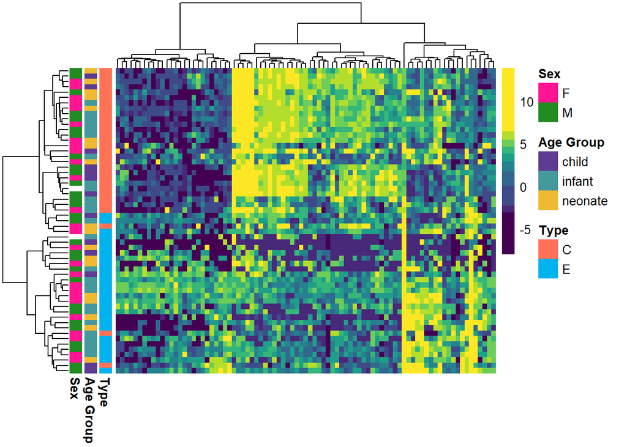

```r
annotation_colors = list("Age Group" = c(child="#5D3C91", infant="#45989B", neonate ="#EFB931"),
                         Type = c(C="coral1", E="deepskyblue2"),
                         Sex = c("F" = "deeppink", M = "forestgreen"))

quantile_breaks <- function(xs, n = 10) {
  breaks <- quantile(xs, probs = seq(0, 1, length.out = n))
  breaks[!duplicated(breaks)]}
mat_breaks <- quantile_breaks(t(hvlcpm), n = 11)

pheatmap(t(hvlcpm),
         cluster_rows = T,
         cluster_cols = T,
         color = viridis(10),
         clustering_distance_cols = "manhattan",
         show_colnames = FALSE,
         show_rownames = FALSE,
         breaks = mat_breaks,
         #scale = "column",
         clustering_method = "ward.D2",
         border_color = NA,
         annotation_row = coldata[,c(1,4,5)],
         annotation_colors = annotation_colors,
         fontsize = 10)
```

# SVAseq Note: Can’t compute latent variables with Patient covariate included in model –> Too many covariates. The matrix t(mod)*mod is singular, det~0 We will focus on DE model with patient random effect and mention surrogate variables in supplement Major revision: adjust for patient random effect in DE model. Minor/Moderate revision: estimate latent variables.